# Hall Effect Sensors

Modified

Mo 2023-04-17 10:05

## The Basics

A Hall effect sensor is a device that responds to magnetic fields. The [Hall effect](https://en.wikipedia.org/wiki/Hall_effect) is a natural phenomenon that occurs when a electrical conductor is exposed to a magnetic field. If the electrical conductor is exposed to the magnetic field in a particular way, a voltage potential or difference will be created across the electrical conductor. A simple way to think of a Hall effect sensor is the opposite of an electromagnet. The strength of a magnetic field may be measured by measuring the voltage difference across the electrical conductor. A simple animation depicting a Hall effect sensor may be found [here](https://upload.wikimedia.org/wikipedia/commons/7/77/Hall_Sensor.webm).

There are many different types of Hall effect sensors that are available. Some of the more common types are digital, latching, and ratiometric. A digital Hall effect sensor is one where it outputs a digital high or low value based on whether the magnetic field it is experiencing is above or below a particular threshold. A latching digital Hall effect sensor is similar to a regular digital Hall effect sensor except that the output stays in the digital high or low state whenever the magnetic field is removed. The sensor is reset by applying the opposite pole of the magnetic field to the sensor. A ratiometric Hall effect sensor output varies proportionally or linearly with the magnetic field it is experiencing.

## Your Sensor

The sensor in your kit is manufactured by Honeywell and its series number is SS490. The datasheet may be found [here](https://sensing.honeywell.com/honeywell-sensing-sensors-linear-hall-effect-ics-ss490-series-datasheet-005843-2-en.pdf). The sensor is a ratiometric Hall effect sensor that requires a supply voltage that ranges from $4.5 V$ to $10.5 V$. The magnetic field that is exposed to the sensor is typically measured in units of Gauss and is a measurement of [magnetic flux density](https://en.wikipedia.org/wiki/Magnetic_field#The_B-field). The units of Gauss are named after [Carl Friedrich Gauss](https://en.wikipedia.org/wiki/Carl_Friedrich_Gauss) who the normal or Gaussian distribution is also named after. Shown below is the response of the sensor

Figure 1: Hall Effect Sensor Response

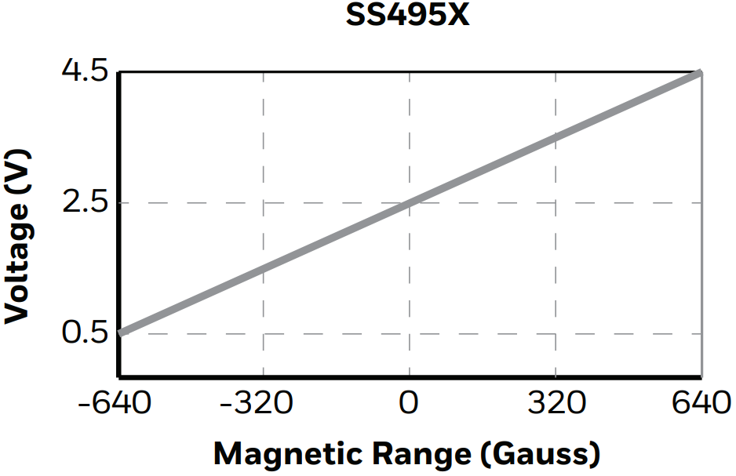

$$m = \frac{4.5 V - 0.5 V}{640 G - \left(- 640 G \right)} = 3.125 \times 10^{-3} \frac{V}{G}$$

While the y-intercept $b$ is

$$b = 2.5 V$$

Thus, the voltage output $V_o$ as a function of the magnetic flux density input $M_i$ is given by

$$V_o = m M_i + b = \left(3.125 \times 10^{-3} \frac{V}{G} \right) M_i + 2.5 V$$

The inverse of this may be found as well. The inverse equation is shown below.

$$M_i = \left( 320 \frac{G}{V} \right) V_o - 800 G$$

## Using The Sensor

Figure 2 below shows a diagram of the Hall effect sensor in your kit and it may be used to determine the correct orientation of the sensor.

Figure 2: Hall Effect Sensor Diagram

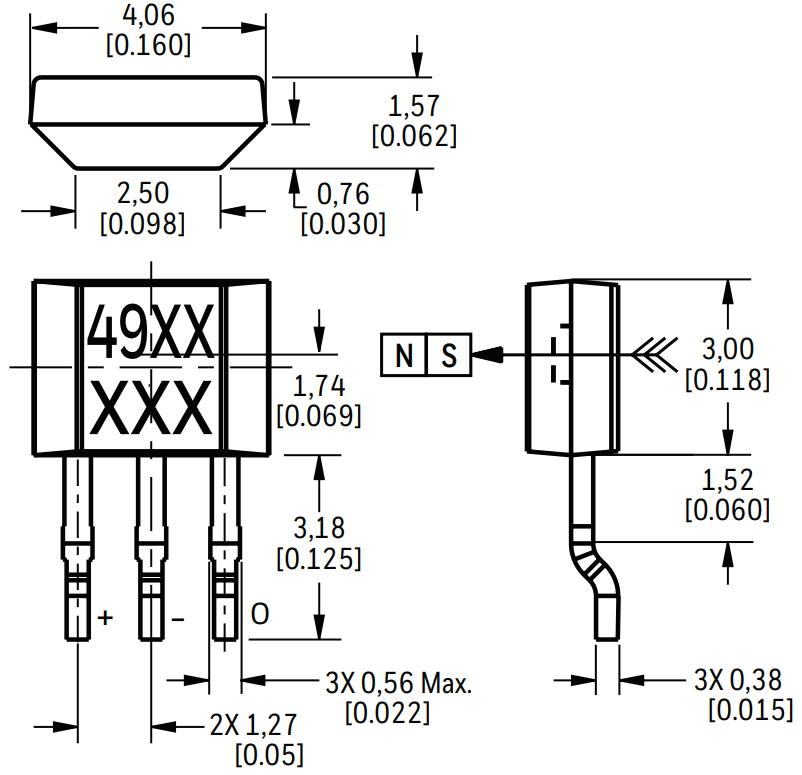

To determine the correct orientation of the sensor, the sensor may be taken between two fingers with the three leads pointing down. When the top of the sensor is rotated towards yourself, the chamfered or angled corners should be pointing down or towards yourself. This is depicted in the Figure 2. Shown in the bottom left is front view and the top view is shown in the top left corner. The three leads are labeled in the bottom left portion of Figure 2. Moving left to right, the lead with the plus sign next to it is the supply voltage pin ($5 V$), the middle lead with the negative sign next to it is the ground pin, and the lead with O beside it is the voltage output pin. The voltage output pin may be connected directly to an Arduino analog pin. Since the Hall effect sensor outputs a voltage directly, there is no need for a voltage divider circuit or any other supporting circuitry. Once those three pins are connected, the Serial Data.ino sketch may be used to display the output of the sensor.